# TF Machine Learning

Fernanda López Franz

2023-09-08

#invoco bibliotecas

```r
library("ggplot2")
library("cluster")
library ("dplyr")
```

#cargo el dataset

```r
library(readxl)
EncuestaPercepciones <- read_excel("data/EncuestaPercepciones.xlsx")
```

## *****************************************Dataset

##ESTRUCTURA #visualizo dataset, primera impresión

```r
head(EncuestaPercepciones)
```

```
## # A tibble: 6 × 148
##    ...1  Edad Género Provincia          Educación Trabajo ¿Cuántas horas por s…¹
##   <dbl> <dbl> <chr>  <chr>              <chr>     <chr>   <chr>
## 1    NA    25 Varón  Buenos Aires       Terciari… Sí      Menos de 35 horas sem…
## 2    NA    31 Mujer  Santa Fe           Terciari… Sí      Entre 35 y 45 horas s…
## 3    NA    53 Varón  Santiago del Este… Universi… Sí      Entre 46 y 50 horas s…
## 4    NA    44 Mujer  Santa Cruz         Terciari… Sí      Menos de 35 horas sem…
## 5    NA    21 Varón  La Pampa           Terciari… Sí      Entre 35 y 45 horas s…
## 6    NA    30 Mujer  Catamarca          Universi… Sí      Menos de 35 horas sem…
## # ℹ abbreviated name: ¹`¿Cuántas horas por semana?`
## # ℹ 141 more variables: `Tu trabajo es:` <chr>,
## #   `¿Cuántas veces por semana asistís al Punto Digital?` <chr>,
## #   `¿Qué tipo de actividades realizás en el Punto Digital? [Alfabetización digital (paquete de office, creación y uso de correo electrónico, alfabetización digital inicial)]` <chr>,
## #   `¿Qué tipo de actividades realizás en el Punto Digital? [Uso del área de entretenimiento]` <chr>,
## #   `¿Qué tipo de actividades realizás en el Punto Digital? [Participación del espacio de microcine (película, cine debate)]` <chr>,
## #   `¿Qué tipo de actividades realizás en el Punto Digital? [Actividades complementarias a la educación (apoyo escolar, terminalidad secundaria, idiomas, otros)]` <chr>, …
```

#dimensión El dataset tiene 148 columnas y 2199 filas

```r
dim(EncuestaPercepciones)
```

```
## [1] 2199  148
```

Columnas

```r
ncol(EncuestaPercepciones)
```

```
## [1] 148
```

Filas

```r
nrow(EncuestaPercepciones)
```

```
## [1] 2199
```

Atributos: 148 preguntas

```r
attributes(EncuestaPercepciones)
```

[output not shown]

[output cut: 297 more lines]

Nombres de las preguntas

```r
attr(EncuestaPercepciones,"names")
```

```
##   [1] "...1"
##   [2] "Edad"
##   [3] "Género"
##   [4] "Provincia"
##   [5] "Educación"
##   [6] "Trabajo"
##   [7] "¿Cuántas horas por semana?"
##   [8] "Tu trabajo es:"
##   [9] "¿Cuántas veces por semana asistís al Punto Digital?"
##  [10] "¿Qué tipo de actividades realizás en el Punto Digital? [Alfabetización digital (paquete de office, creación y uso de correo electrónico, alfabetización digital inicial)]"
##  [11] "¿Qué tipo de actividades realizás en el Punto Digital? [Uso del área de entretenimiento]"
##  [12] "¿Qué tipo de actividades realizás en el Punto Digital? [Participación del espacio de microcine (película, cine debate)]"
##  [13] "¿Qué tipo de actividades realizás en el Punto Digital? [Actividades complementarias a la educación (apoyo escolar, terminalidad secundaria, idiomas, otros)]"
##  [14] "¿Qué tipo de actividades realizás en el Punto Digital? [Formación laboral (inserción laboral, oficios digitales, oficios manuales)]"
##  [15] "¿Qué tipo de actividades realizás en el Punto Digital? [Trámites ]"
```

[output cut: 133 more lines]

El data set es una tabla.

```r
attr(EncuestaPercepciones,"class")
```

```
## [1] "tbl_df"     "tbl"        "data.frame"
```

## *****************************************EDA & dataviz

##DESCRIPCIÓN #columnas, nombres de variables

Consulta: ¿esto podría sacarlo?

```r
names(EncuestaPercepciones)
```

```
##   [1] "...1"
##   [2] "Edad"
##   [3] "Género"
##   [4] "Provincia"
##   [5] "Educación"
##   [6] "Trabajo"
##   [7] "¿Cuántas horas por semana?"
##   [8] "Tu trabajo es:"
##   [9] "¿Cuántas veces por semana asistís al Punto Digital?"
##  [10] "¿Qué tipo de actividades realizás en el Punto Digital? [Alfabetización digital (paquete de office, creación y uso de correo electrónico, alfabetización digital inicial)]"
##  [11] "¿Qué tipo de actividades realizás en el Punto Digital? [Uso del área de entretenimiento]"
##  [12] "¿Qué tipo de actividades realizás en el Punto Digital? [Participación del espacio de microcine (película, cine debate)]"
##  [13] "¿Qué tipo de actividades realizás en el Punto Digital? [Actividades complementarias a la educación (apoyo escolar, terminalidad secundaria, idiomas, otros)]"
##  [14] "¿Qué tipo de actividades realizás en el Punto Digital? [Formación laboral (inserción laboral, oficios digitales, oficios manuales)]"
##  [15] "¿Qué tipo de actividades realizás en el Punto Digital? [Trámites ]"
```

[output cut: 133 more lines]

#histograma, frecuencia La única variable numérica que tenemos, es la Edad. El histograma lo hacemos a partir de ese dato, para observar frecuencias.

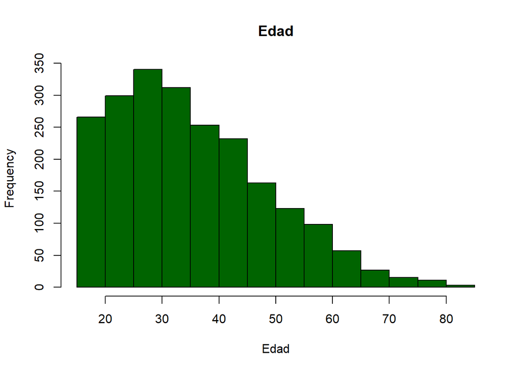

```r
hist(EncuestaPercepciones$Edad,
     col="darkgreen",
     main='Edad',
     xlab='Edad',
     ylab='Frequency')
```

#summarize del dataset, distribución, boxplot

Resumen del dataset

```r
summary(EncuestaPercepciones)
```

[output not shown]

[output cut: 977 more lines]

[output not shown]

#calculo medias

Media por género.

```r
EP_media <- aggregate(EncuestaPercepciones$Edad,
                        list(EncuestaPercepciones$Género),
                        mean) %>%
  print()
```

```
##                     Group.1        x
## 1                     Mujer 36.69133
## 2               Mujer trans 31.50000
## 3                No binario 27.00000
## 4 Prefiero no especificarlo 32.00000
## 5                  Travesti 21.33333
## 6                     Varón 34.81863
## 7               Varón trans 35.00000
```

Media por provincia.

```r
EP_media_prov<- aggregate(EncuestaPercepciones$Edad,
                        list(EncuestaPercepciones$Provincia),
                        mean) %>%
  print()
```

```
##                                                  Group.1        x
## 1                                           Buenos Aires 36.16405
## 2                                              Catamarca 35.12195
## 3                                                  Chaco 31.18750
## 4                                                 Chubut 36.73684
## 5                        Ciudad Autónoma de Buenos Aires 31.76471
## 6                                                Córdoba 37.67188
## 7                                             Corrientes 32.15625
## 8                                             Entre Ríos 35.24896
## 9                                                Formosa 30.61111
## 10                                                 Jujuy 33.87342
## 11                                              La Pampa 27.64286
## 12                                              La Rioja 35.00000
## 13                                               Mendoza 38.23256
## 14                                              Misiones 31.95620
## 15                                               Neuquén 34.55172
## 16                                             Río Negro 36.58182
## 17                                                 Salta 36.32787
## 18                                              San Juan 41.82258
## 19                                              San Luis 37.91892
## 20                                            Santa Cruz 42.34783
## 21                                              Santa Fe 37.86719
## 22                                   Santiago del Estero 37.42857
## 23 Tierra del Fuego, Antártida e Islas del Atlántico Sur 36.00000
## 24                                               Tucumán 35.06164
```

Media por educación: para las personas con primaria incompleta, el promedio de edad sube a 47 años.

```r
EDU_edad <- aggregate(EncuestaPercepciones$Edad,
                        list(EncuestaPercepciones$Educación),
                        mean) %>%
  arrange(desc(x)) %>%
  print()
```

```
##                        Group.1        x
## 1          Primaria incompleta 47.04762
## 2  Post universitario completo 46.11111
## 3            Primaria completa 43.20619
## 4                 Sin estudios 40.00000
## 5           Terciario completo 39.21260
## 6       Universitario completo 38.89806
## 7         Terciario incompleto 35.45600
## 8     Universitario incompleto 33.89200
## 9          Secundaria completa 33.37598
## 10       Secundaria incompleta 31.52218
## 11                       Ns/Nc 25.00000
```

Promedio de edad y consideración de la tecnología como Derecho Humano: si bien no podemos observar varianzas significativas entre las diferentes edades, podemos observar el el promedio de edad desciende entre quienes consideran la tecnología como derecho humano.

```r
EP_media <- aggregate(EncuestaPercepciones$Edad,
                        list(EncuestaPercepciones$La_tecnología_es_un_DDHH),
                        mean) %>%
  rename(Tecnología_como_DDHH=Group.1,Edad=x) %>%

  print()
```

```
##   Tecnología_como_DDHH     Edad
## 1                   No 39.30693
## 2                   Si 35.57320
```